# Deer Reproduction & Disease Control: Statistical Analyses (part 3)

*Damian Satterthwaite-Phillips*

### Litter Sizes

Next we turn to the affect of culling intensity on the litter size, or number of fetuses per pregnancy.

We will consider the same predictors as before. But first, look at the distribution of the response (number of fetuses), which for this analysis we exclude does that were not pregnant.

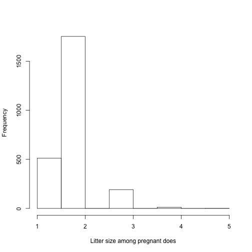

```r
hist(deerF1$fetusNo[deerF1$fetusNo > 0], main = '',
     xlab = 'Litter size among pregnant does')
```

```r
shapiro.test(deerF1$fetusNo[deerF1$fetusNo > 0])
```

```
##
##  Shapiro-Wilk normality test
##
## data:  deerF1$fetusNo[deerF1$fetusNo > 0]
## W = 0.70511, p-value < 2.2e-16
```

The response is not normal, and none of the usual transformations will work to normalize the data. But, as these are count data, they mey be sufficiently well-described by a Poisson distribution. Below we compare a simple linear model to a glm with Poisson distributed residuals.

```r
# LM
litter.full = lm(fetusNo ~ (intensity + I(intensity^2) + age +
                 yearF + cwd)^2 + section,
                 data = subset(deerF1, fetusNo > 0 & !is.na(fetusNo)))
litter.red = step(litter.full, direction = 'both', trace = 0)
summary(litter.red)
```

```
##
## Call:
## lm(formula = fetusNo ~ intensity + I(intensity^2) + age + cwd +
##     I(intensity^2):age, data = subset(deerF1, fetusNo > 0 & !is.na(fetusNo)))
##
## Residuals:
##      Min       1Q   Median       3Q      Max
## -1.07018 -0.00365  0.01379  0.05498  2.99635
##
## Coefficients:
##                              Estimate Std. Error t value Pr(>|t|)
## (Intercept)                 1.2599332  0.0378258  33.309   <2e-16 ***
## intensity                  -0.0063178  0.0031472  -2.007   0.0448 *
## I(intensity^2)              0.0004882  0.0002534   1.927   0.0542 .
## ageyearling                 0.5576838  0.0459580  12.135   <2e-16 ***
## ageadult                    0.7437145  0.0393273  18.911   <2e-16 ***
## cwdpos                     -0.1675304  0.0692074  -2.421   0.0156 *
## I(intensity^2):ageyearling -0.0005259  0.0002520  -2.087   0.0370 *
## I(intensity^2):ageadult    -0.0003194  0.0002252  -1.419   0.1562
## ---
## Signif. codes:  0 '***' 0.001 '**' 0.01 '*' 0.05 '.' 0.1 ' ' 1
##
## Residual standard error: 0.4968 on 2445 degrees of freedom
##   (16 observations deleted due to missingness)
## Multiple R-squared:  0.1583, Adjusted R-squared:  0.1559
## F-statistic: 65.71 on 7 and 2445 DF,  p-value: < 2.2e-16
```

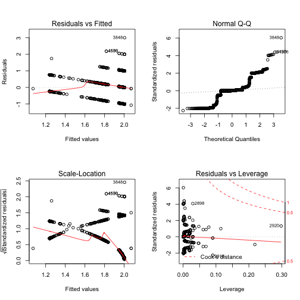

```r
par(mfrow = c(2, 2))
plot(litter.red)
```

```r
# Poisson
litter.full.poiss = glm(fetusNo ~ (intensity + I(intensity^2) + age +
                        yearF + cwd)^2 + section,
                        data = subset(deerF1, fetusNo > 0 & !is.na(fetusNo)),
                        family = poisson)
litter.red.poiss = step(litter.full.poiss, direction = 'both', trace = 0)
```

```
## Error in step(litter.full.poiss, direction = "both", trace = 0): number of rows in use has changed: remove missing values?
```

```r
# Because of missing data, the step function fails to reach its conclusion.
# By setting trace = 1 (or simply omitting the trace argument), the output at
# each iteration is given, so we can manually move the dropped predictors and
# continue.  This is a slightly imperfect solution, because it means that not
# exactly the same underlying data are contibuting to the model, and hence
# AIC values are not directly comparable.  However, given the size of the
# data set, the affect of the missing data points should be minimal.
litter.full.poiss = glm(fetusNo ~ (intensity + I(intensity^2) + age +
                        yearF + cwd)^2 - age:yearF - yearF:cwd -
                        intensity:yearF - I(intensity^2):yearF -
                        yearF - age:cwd - intensity:age - I(intensity^2):age
                        - intensity:cwd - I(intensity^2):cwd -
                        intensity:I(intensity^2) - I(intensity^2) -
                        intensity - cwd,
                        data = subset(deerF1, fetusNo > 0 & !is.na(fetusNo)),
                        family = poisson)
litter.red.poiss = step(litter.full.poiss, direction = 'both', trace = 0)
summary(litter.red.poiss)
```

```
##
## Call:
## glm(formula = fetusNo ~ (intensity + I(intensity^2) + age + yearF +
##     cwd)^2 - age:yearF - yearF:cwd - intensity:yearF - I(intensity^2):yearF -
##     yearF - age:cwd - intensity:age - I(intensity^2):age - intensity:cwd -
##     I(intensity^2):cwd - intensity:I(intensity^2) - I(intensity^2) -
##     intensity - cwd, family = poisson, data = subset(deerF1,
##     fetusNo > 0 & !is.na(fetusNo)))
##
## Deviance Residuals:
##      Min        1Q    Median        3Q       Max
## -0.77005   0.01479   0.01479   0.01479   1.79610
##
## Coefficients:
##             Estimate Std. Error z value Pr(>|z|)
## (Intercept)  0.23270    0.05882   3.956 7.62e-05 ***
## ageyearling  0.34141    0.06975   4.895 9.83e-07 ***
## ageadult     0.44997    0.06113   7.360 1.83e-13 ***
## ---
## Signif. codes:  0 '***' 0.001 '**' 0.01 '*' 0.05 '.' 0.1 ' ' 1
##
## (Dispersion parameter for poisson family taken to be 1)
##
##     Null deviance: 397.21  on 2452  degrees of freedom
## Residual deviance: 332.80  on 2450  degrees of freedom
##   (16 observations deleted due to missingness)
## AIC: 6516.1
##
## Number of Fisher Scoring iterations: 4
```

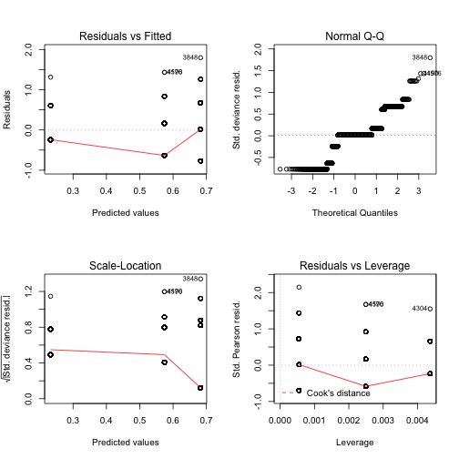

```r
plot(litter.red.poiss)
```

```r
# Gamma
litter.full.gamma = glm(fetusNo ~ (intensity + I(intensity^2) + age +
                        yearF + cwd)^2 + section,
                        data = subset(deerF1, fetusNo > 0 & !is.na(fetusNo)),
                        family = Gamma(link = 'inverse'))
litter.red.gamma = step(litter.full.gamma, direction = 'both', trace = 0)
summary(litter.red.gamma)
```

```
##
## Call:
## glm(formula = fetusNo ~ intensity + I(intensity^2) + age + yearF +
##     cwd + I(intensity^2):age + age:yearF, family = Gamma(link = "inverse"),
##     data = subset(deerF1, fetusNo > 0 & !is.na(fetusNo)))
##
## Deviance Residuals:
##      Min        1Q    Median        3Q       Max
## -0.64682  -0.02357   0.00922   0.04057   1.15094
##
## Coefficients:
##                              Estimate Std. Error t value Pr(>|t|)
## (Intercept)                 1.000e+00  1.553e-01   6.439 1.45e-10 ***
## intensity                   1.883e-03  9.468e-04   1.989  0.04685 *
## I(intensity^2)             -2.036e-04  9.765e-05  -2.085  0.03714 *
## ageyearling                -3.333e-01  1.793e-01  -1.859  0.06320 .
## ageadult                   -4.946e-01  1.572e-01  -3.145  0.00168 **
## yearF2004                  -1.237e-01  1.618e-01  -0.764  0.44472
## yearF2005                  -1.510e-01  1.632e-01  -0.925  0.35484
## yearF2006                  -2.204e-01  1.611e-01  -1.368  0.17154
## yearF2007                  -2.010e-01  1.592e-01  -1.262  0.20707
## yearF2008                  -2.550e-01  1.589e-01  -1.605  0.10868
## yearF2009                  -2.693e-01  1.618e-01  -1.664  0.09618 .
## yearF2010                  -1.578e-01  1.656e-01  -0.953  0.34059
## yearF2011                  -2.911e-01  1.621e-01  -1.796  0.07263 .
## yearF2012                  -1.173e-01  1.635e-01  -0.717  0.47339
## cwdpos                      4.643e-02  2.130e-02   2.180  0.02934 *
## I(intensity^2):ageyearling  2.321e-04  9.965e-05   2.329  0.01995 *
## I(intensity^2):ageadult     1.567e-04  9.130e-05   1.717  0.08619 .
## ageyearling:yearF2004      -2.928e-02  1.868e-01  -0.157  0.87545
## ageadult:yearF2004          1.278e-01  1.641e-01   0.779  0.43615
## ageyearling:yearF2005       4.118e-02  1.884e-01   0.219  0.82700
## ageadult:yearF2005          1.486e-01  1.654e-01   0.898  0.36916
## ageyearling:yearF2006       1.712e-01  1.865e-01   0.918  0.35880
## ageadult:yearF2006          1.994e-01  1.633e-01   1.221  0.22212
## ageyearling:yearF2007       3.524e-02  1.837e-01   0.192  0.84787
## ageadult:yearF2007          2.004e-01  1.613e-01   1.242  0.21441
## ageyearling:yearF2008       1.576e-01  1.834e-01   0.859  0.39024
## ageadult:yearF2008          2.379e-01  1.610e-01   1.478  0.13963
## ageyearling:yearF2009       1.374e-01  1.866e-01   0.736  0.46166
## ageadult:yearF2009          2.603e-01  1.639e-01   1.588  0.11234
## ageyearling:yearF2010       3.004e-02  1.901e-01   0.158  0.87446
## ageadult:yearF2010          1.624e-01  1.678e-01   0.968  0.33318
## ageyearling:yearF2011       1.722e-01  1.863e-01   0.925  0.35530
## ageadult:yearF2011          2.876e-01  1.642e-01   1.752  0.07993 .
## ageyearling:yearF2012       2.587e-02  1.880e-01   0.138  0.89053
## ageadult:yearF2012          1.016e-01  1.657e-01   0.613  0.53970
## ---
## Signif. codes:  0 '***' 0.001 '**' 0.01 '*' 0.05 '.' 0.1 ' ' 1
##
## (Dispersion parameter for Gamma family taken to be 0.07236807)
##
##     Null deviance: 231.68  on 2452  degrees of freedom
## Residual deviance: 189.05  on 2418  degrees of freedom
##   (16 observations deleted due to missingness)
## AIC: 3640.1
##
## Number of Fisher Scoring iterations: 5
```

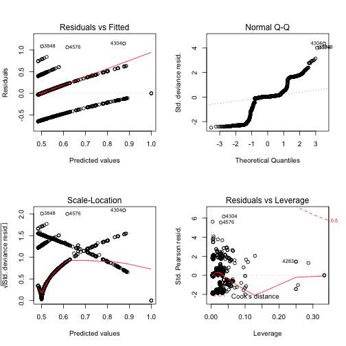

```r
plot(litter.red.gamma)
```

For glms the r<sup>2</sup> statistic cannot be computed as usual, but Nagelkere's method (sometimes called the pseudo-r<sup>2),</sup> found in the fmsb library can be used instead.

```r
library(fmsb)
NagelkerkeR2(litter.red.poiss)
```

```
## $N
## [1] 2453
##
## $R2
## [1] 0.1733489
```

```r
NagelkerkeR2(litter.red.gamma)
```

```
## $N
## [1] 2453
##
## $R2
## [1] 0.1911779
```

```r
# ?NagelkerkeR2 # for details
```

As we can see, both the fit and the diagnostics of the glm are much better. If we want to obtain the p value for each categorical value as a whole, we can use the aov (analysis of variance), function. And if we wish to look at pairwise differences, then we use Tukey's Honest Significant Differences to adjust the p value to compensate for the fact that we are making multiple comparisons.

The results of the glm indicate that the age of the mother, sharpshooting intensity, CWD status, and age-intensity interactions are all significant. As we are primarily interested in the effects of the culling, we visualize.

Recalling that glms typically transform the response according to the link function, we must perform the inverse function to get the results back in the original units. Again we use the 'typical' year.

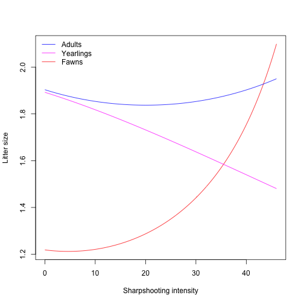

```r
yrCoef = median(c(0, coef(litter.red.gamma)[6:14]))
yYrCoef = median(coef(litter.red.gamma)[seq(18, 34, 2)])
aYrCoef = median(coef(litter.red.gamma)[seq(19, 35, 2)])

intV = seq(min(deerF1$intensity, na.rm = T),
           max(deerF1$intensity, na.rm = T), length = 100)

litter.pred = function(int, yrl, ad, dis) {
    pred = 1 + 0.001883*int - 0.0002036*int^2 - 0.3333*yrl - 0.4946*ad +
           yrCoef + 0.04643*dis + 0.0002321*int^2*yrl + 0.0001567*int^2*ad +
           yYrCoef*yrl + aYrCoef*ad
    1 / pred
}

fPred = litter.pred(intV, F, F, dis = F)
yPred = litter.pred(intV, T, F, dis = F)
aPred = litter.pred(intV, F, T, dis = F)

plot(fPred ~ intV, type = 'l', col = 2,
     ylim = range(fPred, yPred, aPred), xlab = 'Sharpshooting intensity',
     ylab = "Litter size")
lines(yPred ~ intV, col = 6)
lines(aPred ~ intV, col = 4)
legend('topleft', lty = 1, col = c(4, 6, 2),
       legend = c('Adults', 'Yearlings', 'Fawns'), bty = 'n')
```

We might instead fit separate models to each age class, or try another approach altogether, as the main difficulty seems to be in accurately representing the response distribution.

##### Separate Gamma-Distributed GLMs

```r
flitter.full.gamma = glm(fetusNo ~ (intensity + I(intensity^2) +
                         yearF + cwd)^2 + section,
                         data = subset(deerF1,
                                       age == 'fawn' &
                                       fetusNo > 0 &
                                       !is.na(fetusNo)),
                        family = Gamma(link = 'inverse'))
flitter.red.gamma = step(flitter.full.gamma, direction = 'both', trace = 0)
```

```
## Error in step(flitter.full.gamma, direction = "both", trace = 0): number of rows in use has changed: remove missing values?
```

```r
flitter.full.gamma = glm(fetusNo ~ (intensity + I(intensity^2) +
                         yearF + cwd)^2 - intensity:cwd - cwd - yearF:cwd -
                         I(intensity^2):cwd - intensity:I(intensity^2) -
                         I(intensity^2):yearF - intensity:yearF - yearF -
                         intensity - I(intensity^2),
                         data = subset(deerF1,
                                       age == 'fawn' &
                                       fetusNo > 0 &
                                       !is.na(fetusNo)),
                        family = Gamma(link = 'inverse'))
flitter.red.gamma = step(flitter.full.gamma, direction = 'both', trace = 0)
summary(flitter.red.gamma)
```

```
##
## Call:
## glm(formula = fetusNo ~ (intensity + I(intensity^2) + yearF +
##     cwd)^2 - intensity:cwd - cwd - yearF:cwd - I(intensity^2):cwd -
##     intensity:I(intensity^2) - I(intensity^2):yearF - intensity:yearF -
##     yearF - intensity - I(intensity^2), family = Gamma(link = "inverse"),
##     data = subset(deerF1, age == "fawn" & fetusNo > 0 & !is.na(fetusNo)))
##
## Deviance Residuals:
##     Min       1Q   Median       3Q      Max
## -0.2240  -0.2240  -0.2240   0.4987   1.0112
##
## Coefficients:
##             Estimate Std. Error t value Pr(>|t|)
## (Intercept)  0.79239    0.01869   42.39   <2e-16 ***
## ---
## Signif. codes:  0 '***' 0.001 '**' 0.01 '*' 0.05 '.' 0.1 ' ' 1
##
## (Dispersion parameter for Gamma family taken to be 0.1274468)
##
##     Null deviance: 23.976  on 228  degrees of freedom
## Residual deviance: 23.976  on 228  degrees of freedom
##   (1 observation deleted due to missingness)
## AIC: 223.7
##
## Number of Fisher Scoring iterations: 5
```

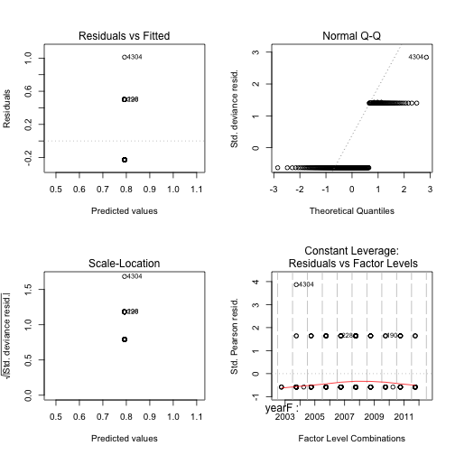

```r
par(mfrow = c(2, 2))
plot(flitter.red.gamma)
```

```r
ylitter.full.gamma = glm(fetusNo ~ (intensity + I(intensity^2) +
                         yearF + cwd)^2 + section,
                         data = subset(deerF1,
                                       age == 'yearling' &
                                       fetusNo > 0 &
                                       !is.na(fetusNo)),
                        family = Gamma(link = 'inverse'))
ylitter.red.gamma = step(ylitter.full.gamma, direction = 'both', trace = 0)
```

```
## Error in step(ylitter.full.gamma, direction = "both", trace = 0): number of rows in use has changed: remove missing values?
```

```r
ylitter.full.gamma = glm(fetusNo ~ (intensity + I(intensity^2) +
                         yearF + cwd)^2 - I(intensity^2):yearF - yearF:cwd -
                         intensity:yearF - yearF - intensity:cwd - cwd -
                         I(intensity^2):cwd,
                         data = subset(deerF1,
                                       age == 'yearling' &
                                       fetusNo > 0 &
                                       !is.na(fetusNo)),
                        family = Gamma(link = 'inverse'))
ylitter.red.gamma = step(ylitter.full.gamma, direction = 'both', trace = 0)
summary(ylitter.red.gamma)
```

```
##
## Call:
## glm(formula = fetusNo ~ (intensity + I(intensity^2) + yearF +
##     cwd)^2 - I(intensity^2):yearF - yearF:cwd - intensity:yearF -
##     yearF - intensity:cwd - cwd - I(intensity^2):cwd, family = Gamma(link = "inverse"),
##     data = subset(deerF1, age == "yearling" & fetusNo > 0 & !is.na(fetusNo)))
##
## Deviance Residuals:
##     Min       1Q   Median       3Q      Max
## -0.5453  -0.4446   0.1018   0.1110   0.9136
##
## Coefficients:
##                            Estimate Std. Error t value Pr(>|t|)
## (Intercept)               5.526e-01  1.288e-02  42.913   <2e-16 ***
## intensity                -2.877e-03  4.859e-03  -0.592   0.5541
## I(intensity^2)            5.987e-04  3.920e-04   1.527   0.1275
## intensity:I(intensity^2) -1.249e-05  7.213e-06  -1.732   0.0841 .
## ---
## Signif. codes:  0 '***' 0.001 '**' 0.01 '*' 0.05 '.' 0.1 ' ' 1
##
## (Dispersion parameter for Gamma family taken to be 0.09383169)
##
##     Null deviance: 43.008  on 400  degrees of freedom
## Residual deviance: 42.237  on 397  degrees of freedom
##   (1 observation deleted due to missingness)
## AIC: 669.94
##
## Number of Fisher Scoring iterations: 5
```

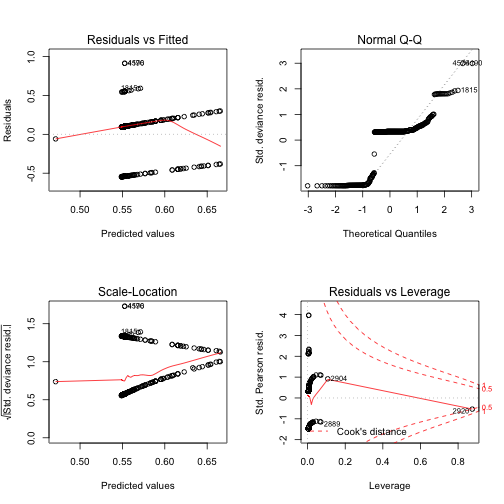

```r
plot(ylitter.red.gamma)
```

```r
alitter.full.gamma = glm(fetusNo ~ (intensity + I(intensity^2) +
                         yearF + cwd)^2 + section,
                         data = subset(deerF1,
                                       age == 'adult' &
                                       fetusNo > 0 &
                                       !is.na(fetusNo)),
                        family = Gamma(link = 'inverse'))
alitter.red.gamma = step(alitter.full.gamma, direction = 'both', trace = 0)
```

```
## Error in step(alitter.full.gamma, direction = "both", trace = 0): number of rows in use has changed: remove missing values?
```

```r
alitter.full.gamma = glm(fetusNo ~ (intensity + I(intensity^2) +
                         yearF + cwd)^2 - intensity:yearF -
                         yearF:cwd - I(intensity^2):yearF -
                         yearF - intensity:(intensity^2) - intensity:cwd -
                         I(intensity^2):cwd - I(intensity^2) - intensity -
                         intensity:I(intensity^2),
                         data = subset(deerF1,
                                       age == 'adult' &
                                       fetusNo > 0 &
                                       !is.na(fetusNo)),
                        family = Gamma(link = 'inverse'))
alitter.red.gamma = step(alitter.full.gamma, direction = 'both', trace = 0)
summary(alitter.red.gamma)
```

```
##
## Call:
## glm(formula = fetusNo ~ (intensity + I(intensity^2) + yearF +
##     cwd)^2 - intensity:yearF - yearF:cwd - I(intensity^2):yearF -
##     yearF - intensity:(intensity^2) - intensity:cwd - I(intensity^2):cwd -
##     I(intensity^2) - intensity - intensity:I(intensity^2), family = Gamma(link = "inverse"),
##     data = subset(deerF1, age == "adult" & fetusNo > 0 & !is.na(fetusNo)))
##
## Deviance Residuals:
##      Min        1Q    Median        3Q       Max
## -0.61471   0.00847   0.00847   0.00847   1.09224
##
## Coefficients:
##             Estimate Std. Error t value Pr(>|t|)
## (Intercept) 0.504249   0.002969 169.816   <2e-16 ***
## cwdpos      0.047033   0.021096   2.229   0.0259 *
## ---
## Signif. codes:  0 '***' 0.001 '**' 0.01 '*' 0.05 '.' 0.1 ' ' 1
##
## (Dispersion parameter for Gamma family taken to be 0.0617263)
##
##     Null deviance: 126.52  on 1822  degrees of freedom
## Residual deviance: 126.19  on 1821  degrees of freedom
##   (11 observations deleted due to missingness)
## AIC: 2694.8
##
## Number of Fisher Scoring iterations: 4
```

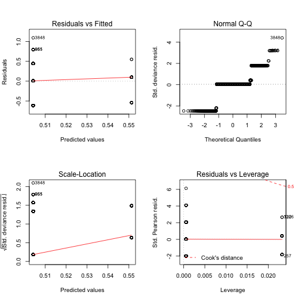

```r
plot(alitter.red.gamma)
```

```r
NagelkerkeR2(flitter.red.gamma)
```

```
## $N
## [1] 229
##
## $R2
## [1] 0
```

```r
NagelkerkeR2(ylitter.red.gamma)
```

```
## $N
## [1] 401
##
## $R2
## [1] 0.01889472
```

```r
NagelkerkeR2(alitter.red.gamma)
```

```
## $N
## [1] 1823
##
## $R2
## [1] 0.002655567
```

At this point our models conflict, and it remains unclear if the culling is significantly affecting litter sizes. To investigate this further, we relax the model by using a generalized additive model to smooth the effects of intensity with a non-parametric smoother. In the following code, intensity is smoothed using splines (s()), and the mgcv package determines the degree of smoothing automatically. (The gam library provides the alternate smoothing methods.) The initial model is the same as the glm above, but with intensity smoothed with splines instead of using the parametric fit as above. AICs are provided, but because the estimates are approximated, I also ran ANOVAs at each reduction step to compare the competing models. The method for simplifying was to prefer simpler models when they did not differ significantly, and at each round of reductions, to prefer the model with the lowest AIC. The models that were rejected are not shown below.

```r
library(mgcv)

litter.gam = gam(fetusNo ~ s(intensity) + age + yearF + cwd + section +
                 intensity:age + age:yearF,
                 data = subset(deerF1, fetusNo > 0 & !is.na(fetusNo)),
                 family = Gamma(link = 'inverse'))
summary(litter.gam)
```

```
##
## Family: Gamma
## Link function: inverse
##
## Formula:
## fetusNo ~ s(intensity) + age + yearF + cwd + section + intensity:age +
##     age:yearF
##
## Parametric coefficients:
##                         Estimate Std. Error t value Pr(>|t|)
## (Intercept)            1.1525420  0.1827814   6.306 3.48e-10 ***
## ageyearling           -0.4142008  0.1861837  -2.225  0.02621 *
## ageadult              -0.5262402  0.1616008  -3.256  0.00115 **
## yearF2004             -0.1183679  0.1658968  -0.714  0.47561
## yearF2005             -0.1692739  0.1675339  -1.010  0.31242
## yearF2006             -0.2307886  0.1651279  -1.398  0.16237
## yearF2007             -0.2034242  0.1631766  -1.247  0.21266
## yearF2008             -0.2454824  0.1629575  -1.506  0.13211
## yearF2009             -0.2691796  0.1658404  -1.623  0.10471
## yearF2010             -0.1363861  0.1697861  -0.803  0.42190
## yearF2011             -0.2988580  0.1663671  -1.796  0.07258 .
## yearF2012             -0.0855799  0.1692396  -0.506  0.61314
## cwdpos                 0.0439360  0.0225838   1.945  0.05185 .
## section333N5E14       -0.1407975  0.1041301  -1.352  0.17648
## section333N5E15       -0.1479524  0.0966746  -1.530  0.12606
## section333N5E17       -0.1687749  0.0983328  -1.716  0.08624 .
## ...other sections omitted for brevity...
## agefawn:intensity     -0.0032839  0.0022913  -1.433  0.15195
## ageyearling:intensity  0.0023130  0.0013736   1.684  0.09235 .
## ageadult:intensity     0.0007129  0.0008167   0.873  0.38282
## ageyearling:yearF2004  0.0523129  0.1939211   0.270  0.78737
## ageadult:yearF2004     0.1606460  0.1688241   0.952  0.34143
## ageyearling:yearF2005  0.1202177  0.1963964   0.612  0.54052
## ageadult:yearF2005     0.1991750  0.1706082   1.167  0.24316
## ageyearling:yearF2006  0.2413220  0.1939214   1.244  0.21348
## ageadult:yearF2006     0.2255708  0.1681404   1.342  0.17988
## ageyearling:yearF2007  0.1168551  0.1911211   0.611  0.54099
## ageadult:yearF2007     0.2257529  0.1662510   1.358  0.17464
## ageyearling:yearF2008  0.2248525  0.1910058   1.177  0.23925
## ageadult:yearF2008     0.2498176  0.1659429   1.505  0.13236
## ageyearling:yearF2009  0.2088084  0.1944207   1.074  0.28294
## ageadult:yearF2009     0.2838782  0.1688749   1.681  0.09291 .
## ageyearling:yearF2010  0.0772320  0.1975596   0.391  0.69589
## ageadult:yearF2010     0.1606332  0.1731553   0.928  0.35368
## ageyearling:yearF2011  0.2488005  0.1938636   1.283  0.19950
## ageadult:yearF2011     0.3105476  0.1692138   1.835  0.06661 .
## ageyearling:yearF2012  0.0462638  0.1970684   0.235  0.81442
## ageadult:yearF2012     0.0820322  0.1723202   0.476  0.63409
## ---
## Signif. codes:  0 '***' 0.001 '**' 0.01 '*' 0.05 '.' 0.1 ' ' 1
##
## Approximate significance of smooth terms:
##                 edf Ref.df     F p-value
## s(intensity) 0.1208 0.2314 0.269   0.803
##
## Rank: 315/316
## R-sq.(adj) =  0.156   Deviance explained = 26.7%
## GCV = 0.09047  Scale est. = 0.0732    n = 2453
```

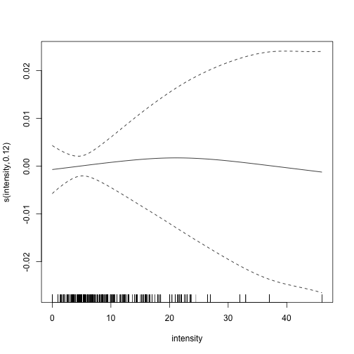

```r
# To see the effect of the smoothing relative to the linear predictor:
par(mfrow = c(1, 1))
plot(litter.gam)
```

```r
AIC(litter.gam)
```

```
## [1] 3918.228
```

```r
litter.gam2 = update(litter.gam, .~. - section)
anova(litter.gam, litter.gam2) # res.dev = 189.11
```

```
## Analysis of Deviance Table
##
## Model 1: fetusNo ~ s(intensity) + age + yearF + cwd + section + intensity:age +
##     age:yearF
## Model 2: fetusNo ~ s(intensity) + age + yearF + cwd + age:intensity +
##     age:yearF
##   Resid. Df Resid. Dev      Df Deviance
## 1    2145.9     169.83
## 2    2418.7     189.11 -272.84  -19.282
```

```r
AIC(litter.gam2)
```

```
## [1] 3639.563
```

```r
litter.gam3 = update(litter.gam2, .~. - yearF)
anova(litter.gam2, litter.gam3) # res.dev = 189.11
```

```
## Analysis of Deviance Table
##
## Model 1: fetusNo ~ s(intensity) + age + yearF + cwd + age:intensity +
##     age:yearF
## Model 2: fetusNo ~ s(intensity) + age + cwd + age:intensity + age:yearF
##   Resid. Df Resid. Dev Df   Deviance
## 1    2418.7     189.11
## 2    2418.7     189.11  0 2.8422e-14
```

```r
AIC(litter.gam3)
```

```
## [1] 3639.563
```

```r
litter.gam4 = update(litter.gam3, .~. - age:yearF)
anova(litter.gam3, litter.gam4) # res.dev = 192.36
```

```
## Analysis of Deviance Table
##
## Model 1: fetusNo ~ s(intensity) + age + cwd + age:intensity + age:yearF
## Model 2: fetusNo ~ s(intensity) + age + cwd + age:intensity
##   Resid. Df Resid. Dev      Df Deviance
## 1    2418.7     189.11
## 2    2445.8     192.36 -27.132  -3.2514
```

```r
AIC(litter.gam4)
```

```
## [1] 3627.657
```